# Marketing Analytics

Chapter 1 · Marketing Analytics as Decision-Making

Nils Wlömert

Vienna University of Economics and Business (WU)

October 2026

## Who I am…

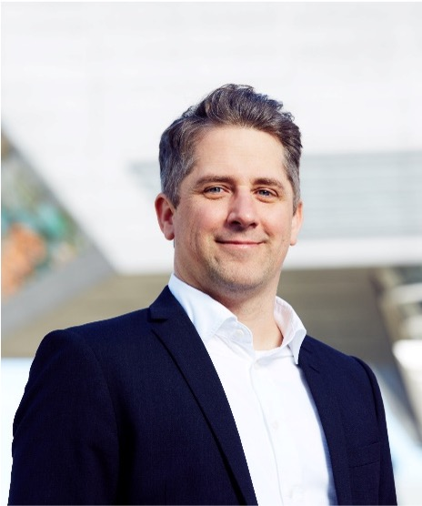

**Contact**

Univ.Prof. Dr. Nils Wlömert  
Room D2.1.452  
nils.wloemert@wu.ac.at  
T +43 1 31336 4958  
sites.google.com/view/nilswloemert

- **Professor** of Marketing, Vienna University of Economics and Business, Institute for Retailing & Data Science, since 2021
- **Assistant Professor** of Marketing, Vienna University of Economics and Business, Institute for Interactive Marketing & Social Media, 2015–2020
- **Ph.D.** in Marketing, University of Hamburg, 2010–2014
- **Dissertation topic:** “Information Technology and Online Content Distribution”
- **Universal Music Group:** Business Analyst & Digital Marketing Manager, 2008–2010
- **Research interests:** multi-channel distribution, online content distribution, digital business models, marketing modeling, e-commerce policies, information goods, targeting & consumer privacy …

## Institut für Retailing & Data Science

[figure not shown]

[figure not shown]

Follow us on LinkedIn!

[linkedin.com/company/institut-für-retailing-data-science-rds](https://www.linkedin.com/company/institut-f%C3%BCr-retailing-data-science-rds/)

## Contacts

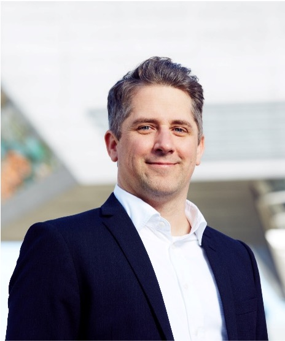

**Lecture & group project**

Univ.Prof. Dr. Nils Wlömert  
nils.wloemert@wu.ac.at

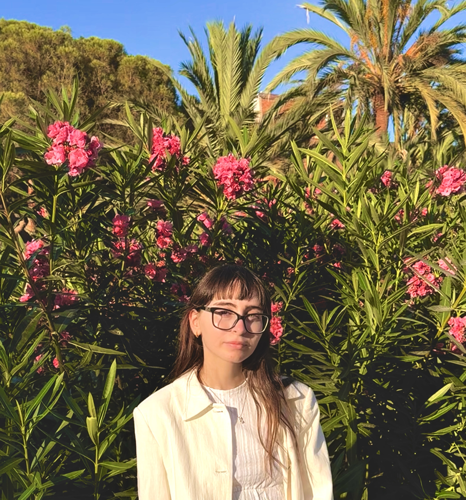

**Assignments**

Anna Di Donato  
anna.di.donato@wu.ac.at  
Consultation hours: Fridays 3:00PM - 5:00PM (by appointment)

**Before you write an email:** course site → AI tools / forum on Canvas → ask in class. If you have the question, so do five others.

## Before we start: who are you?

Go to **menti.com**  
and enter code **2171 2732**

- Your background & prior R experience
- What you want to get out of this course

[figure not shown]

# Course organization

## How this course works

**Weekly sessions & self-study**

- **Weekly in-person sessions** (see schedule) — concepts, live analysis, discussion, and lots of time for questions
- **Self-study *after* each session:** the course book on the website consolidates the session — chapter text, commented code, and a learning check; slides, code & PDF handouts linked from every chapter
- Each session opens with a short **paper quiz** on the previous chapter *(counts toward participation)*
- **Before session 2:** complete the self-paced **R onboarding module** (install R/RStudio)

**Applying the knowledge**

- **Three individual assignments** transfer the methods to new business settings — reproducible reports (.Rmd), submitted via Canvas, short in-class debrief *(details in a moment)*
- **Group project:** design & conduct a real market research project — two coaching sessions, results submitted as a **pre-recorded video presentation**

**Getting help**

- **Forum on Canvas** / **AI-Tools** first; then coaching sessions & in-person sessions

## Schedule — Group A (Mondays)

| # | Date | Time | Room | Topic |
| --- | --- | --- | --- | --- |
| 1 | Mon, Oct 5 | 13:00–16:00 | TC.4.03 | Questions, decisions & data |
| 2 | Mon, Oct 12 | 13:00–17:00 | D3.0.233 | Describing data |
| 3 | Mon, Oct 19 | 13:00–17:00 | D3.0.233 | Uncertainty & Experiments I |
| 4 | Tue, Oct 27 | 13:00–16:00 | TC.5.05 | Experiments II |
| 5 | Mon, Nov 2 | 13:00–16:00 | TC.4.03 | Observational data I |
| 6 | Mon, Nov 9 | 13:00–16:00 | TC.4.03 | Observational data II |
| 7 | Mon, Nov 16 | 13:00–16:00 | TC.4.03 | Mechanisms & heterogeneity |
| 8 | Mon, Nov 23 | 13:00–16:00 | TC.4.03 | Survey design |

## Assignments — Group A (Mondays)

| # | Topic | Hand-out | Submission | Debrief |
| --- | --- | --- | --- | --- |
| A1 | Data handling & description in R | Mon, Oct 12 | Mon, Oct 26 | Tue, Oct 27 |
| A2 | Analyzing experiments | Tue, Oct 27 | Sun, Nov 8 | Mon, Nov 9 |
| A3 | Analyzing observational data | Mon, Nov 9 | Sun, Nov 22 | Mon, Nov 23 |

- Submitted as a **reproducible report** (.Rmd → HTML) via Canvas — **deadline: the day before the debrief session**
- Every student receives an **individual dataset** — results and conclusions differ **by design**
- **Debrief** = 3 short paper questions about *your* results at the start of the next session — **report 7 + debrief 3 points**; your lowest debrief score is replaced by the average of the other two

[figure not shown]

## Schedule — Group B (Thursdays)

| # | Date | Time | Room | Topic |
| --- | --- | --- | --- | --- |
| 1 | Thu, Oct 8 | 13:00–16:00 | TC.5.03 | Questions, decisions & data |
| 2 | Thu, Oct 15 | 13:30–17:30 | TC.3.03 | Describing data |
| 3 | Thu, Oct 22 | 13:00–17:00 | TC.5.15 | Uncertainty & Experiments I |
| 4 | Thu, Oct 29 | 13:00–16:00 | TC.5.03 | Experiments II |
| 5 | Thu, Nov 5 | 13:00–16:00 | TC.5.03 | Observational data I |
| 6 | Thu, Nov 12 | 13:00–16:00 | TC.5.03 | Observational data II |
| 7 | Thu, Nov 19 | 13:00–16:00 | TC.5.03 | Mechanisms & heterogeneity |
| 8 | Thu, Nov 26 | 13:30–16:30 | TC.3.03 | Survey design |

## Assignments — Group B (Thursdays)

| # | Topic | Hand-out | Submission | Debrief |
| --- | --- | --- | --- | --- |
| A1 | Data handling & description in R | Thu, Oct 15 | Wed, Oct 28 | Thu, Oct 29 |
| A2 | Analyzing experiments | Thu, Oct 29 | Wed, Nov 11 | Thu, Nov 12 |
| A3 | Analyzing observational data | Thu, Nov 12 | Wed, Nov 25 | Thu, Nov 26 |

- Submitted as a **reproducible report** (.Rmd → HTML) via Canvas — **deadline: the day before the debrief session**
- Every student receives an **individual dataset** — results and conclusions differ **by design**
- **Debrief** = 3 short paper questions about *your* results at the start of the next session — **report 7 + debrief 3 points**; your lowest debrief score is replaced by the average of the other two

[figure not shown]

## Group project & final exam — key dates

| Milestone | Group A (Mondays) | Group B (Thursdays) |
| --- | --- | --- |
| Coaching I — questionnaire design *(online)* | Mon, Nov 30, 13:00–17:00 | Thu, Dec 3, 14:00–18:00 |
| Field your survey | December | December |
| Coaching II — data analysis *(online)* | Thu, Jan 7, 13:00–17:00 | Fri, Jan 8, 14:00–18:00 |
| Submission: video presentation | Wed, Jan 20 | Wed, Jan 20 |
| Submission: peer review of one other group’s video | Mon, Jan 25 | Mon, Jan 25 |

**Final exam (both groups):** Tue, **Dec 15**, 10:00–12:00, D5.0.001 — *paper & pencil, open book (slides), in person*

## Our AI policy

**AI assistants are welcome in the assignments** — they may support your work at every step, but not do it for you: a submission without individual contribution earns no credit, disclosed or not. You must be able to **explain everything you submit** (that is what the debrief checks), and each report ends with a short **AI-use disclosure**. Honest disclosure is never penalized; concealing substantial AI use is. The final exam is the unassisted layer: paper & pencil, in person.

“How much AI is allowed?” — As much as you like,  
provided you can stand here and explain what was done and why.

## Use it — but don’t let it study for you

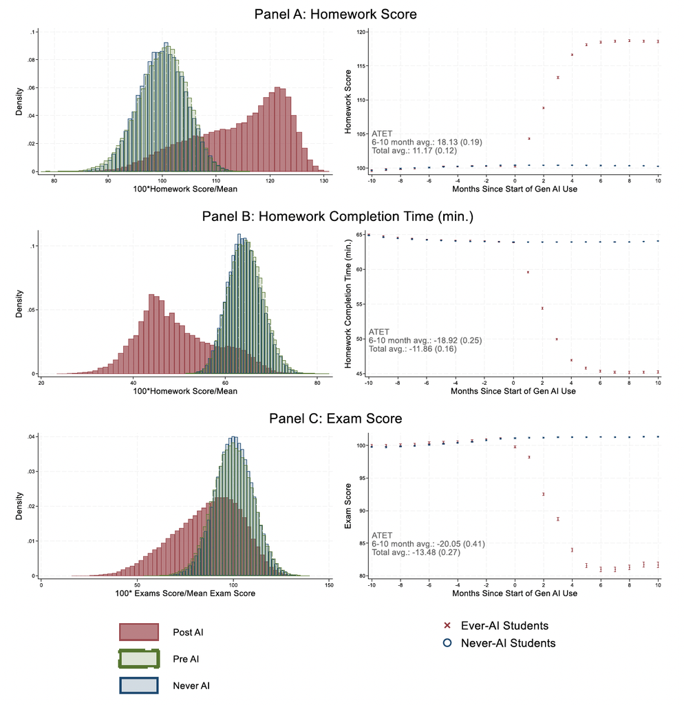

- **26,811 Chinese students**, 30-month panel: AI adoption → homework **+18%**, time **−30%** — but exam scores **−20%**; entrance exams **−18/−24%** after two years
- Driven by the **~80% who outsource**; students who used AI but spent **the same time** on homework: **no learning loss**

Sources: Strömberg, Lei & Wu (2026); Autor et al. (2026, NBER WP 35720); Bastani et al. (2025, PNAS); Kestin et al. (2025). Figures: Strömberg et al. (2026), Fig. 2 — red ×: AI adopters, blue ○: never-AI students.

## Grading

| Component | Weight |
| --- | --- |
| Market research **group project** (design → data collection → analysis → **video presentation**) | 30% |
| Individual **take-home assignments** (3 × reproducible report + **in-class debrief**; each 7 + 3 points) | 30% |
| **Final exam** (concepts & methods — no coding · **course slides may be used**, paper & pencil, in person) | 30% |
| **Class participation** (weekly quizzes · active contributions in class & forum) | 10% |

- Pass threshold I: **60%** weighted total
- Pass threshold II: you need to be present **80%** of the in-class time
- Group project: **peer assessment** + **contribution & AI-use statement** enter the individual grade
- Participation = **quizzes** (up to 6 points, best 6 of 7) **+ active contributions** (up to 6 points, max. 1 per session, incl. forum) — **capped at 10**: strengths in one can compensate for the other
- Assignment dates: see slides · all details on the course site

## Grading scheme

| Overall percentage | Grade |
| --- | --- |
| 90–100% | 1 (excellent) |
| 80–89% | 2 (good) |
| 70–79% | 3 (satisfactory) |
| 60–69% | 4 (sufficient) |
| < 60% | 5 (fail) |

To pass, your **weighted final grade** must reach at least **60%** — across all components combined; there is no minimum per component.

## Course materials

- **Main reference: the course website** — full chapters with explanations, commented R code, and learning checks; **slides & PDF handouts** linked from every chapter
- Everything is **free & always current** — no textbook purchase required
- **Optional further reading** linked on the site
- **Canvas**: assignment hand-outs & submissions, forum, announcements
- Example exams: provided on Canvas **before the exam**

## The group project in one sentence

You will **design a survey containing a real randomized experiment**, field it, analyze the data, and present the results — everything this course teaches, built by you.

*(Details follow — and at the end of today’s session you will see why “randomized” is the most important word in that sentence.)*

## The group project: two parts

**Part 1 · Questionnaire design & data collection**

- Pick a topic: **14 proposed topics** (with starter literature) — or suggest your own
- Design a questionnaire (**≈ 30 questions**, ~5 per member) in **Qualtrics** — free account provided
- Your design contains a **real experiment**: participants randomly assigned to conditions
- **Coaching I:** present your draft (research problem, design, measurement, planned analyses) → feedback → revise
- **Field it:** each member recruits **≈ 20 respondents** → **≈ 120 responses** per group

**Part 2 · Data analysis & presentation**

- Import & clean your Qualtrics data in R
- Analyze: descriptives → your **experimental comparison** → heterogeneity (for whom does it work?)
- **Coaching II:** work through your analysis with us *(online)*
- Submit a **.zip**: pre-recorded **video presentation** + data + reproducible R code + slides
- Afterwards: **peer review** — each of you reviews **one** other group’s video (structured form)

**Individual grades:** peer assessment within the group + a short **contribution & AI-use statement** + your **peer review** of one other video (2 of 30 points).

## Group project: what makes it good

- A **precise research question** with managerial relevance — and hypotheses stated *before* data collection
- A clean **experimental manipulation**: everything constant except the treatment; randomizer placed correctly
- **Keep it simple**: 2 conditions are sufficient (your sample size will be limited)
- **Deliberate measurement:** a dependent variable with real variation (e.g., willingness to pay)
- Incorporate **moderators** to analyse heterogeneous treatment responses
- Incorporate **mediators** to understand the process
- Analyses **matched to the design** — justified test choice, honest uncertainty, assumptions checked
- A presentation that **tells the decision-maker what to do** — not a parade of charts

Full guidelines, topic list, Qualtrics templates & how-tos: **“Group project” section on the course site**.

## Course goals

**After taking this course, you should…**

- …know why analytical skills have become **career-defining** for marketers — and which skills stay scarce when AI does the mechanics
- …know **what data can and cannot tell you** — and recognize which question you are actually asking: *describe, predict, explain, decide*
- …know **when to use which method** — and which assumptions the answer rests on
- …be able to **implement the methods in R** — with AI assistants as accelerators, not replacements
- …be able to **judge analyses made by others** — a colleague’s slide deck, a platform dashboard, an AI-generated report
- …be able to **conduct your own research project** — from question to data to recommendation
- …no longer be **afraid of numbers & statistics** (in case you were)
- …feel the **desire to learn more** about analytics

## Today’s session

**Part A — Why we are here**

1.1 Motivation: data and AI in marketing  
1.2 Case study: search advertising at eBay

**Part B — The framework of the course**

1.3 Types of research questions  
1.4 Correlation and causation  
1.5 Variables and their roles  
1.6 Randomization  
1.7 Quasi-experiments

**Part C — Making it work**

1.8 From business problem to research design  
1.9 The analytics workflow

**One promise for today:** no R output, no tests, and just one simple formula. Concepts and pictures — the machinery follows in later sessions.

# 1.1 Motivation: data and AI in marketing

## “I don’t know which half”

> “Half the money I spend on advertising is wasted; the trouble is I don’t know which half.”

> — John Wanamaker (1838–1922), department store pioneer, Philadelphia

More than 100 years later, **do we know** today which half of the advertising budget is wasted? What **data** would you need to find out?

## Marketing is reorganizing around AI and data

- AI already performs **about a quarter** of marketing activities — nearly **doubled** in two years
- Generative AI alone: from 7.0% to 22.4% of activities (**+220%** in two years)
- Marketing leaders expect **more than half** of marketing work to be performed by AI **within three years**

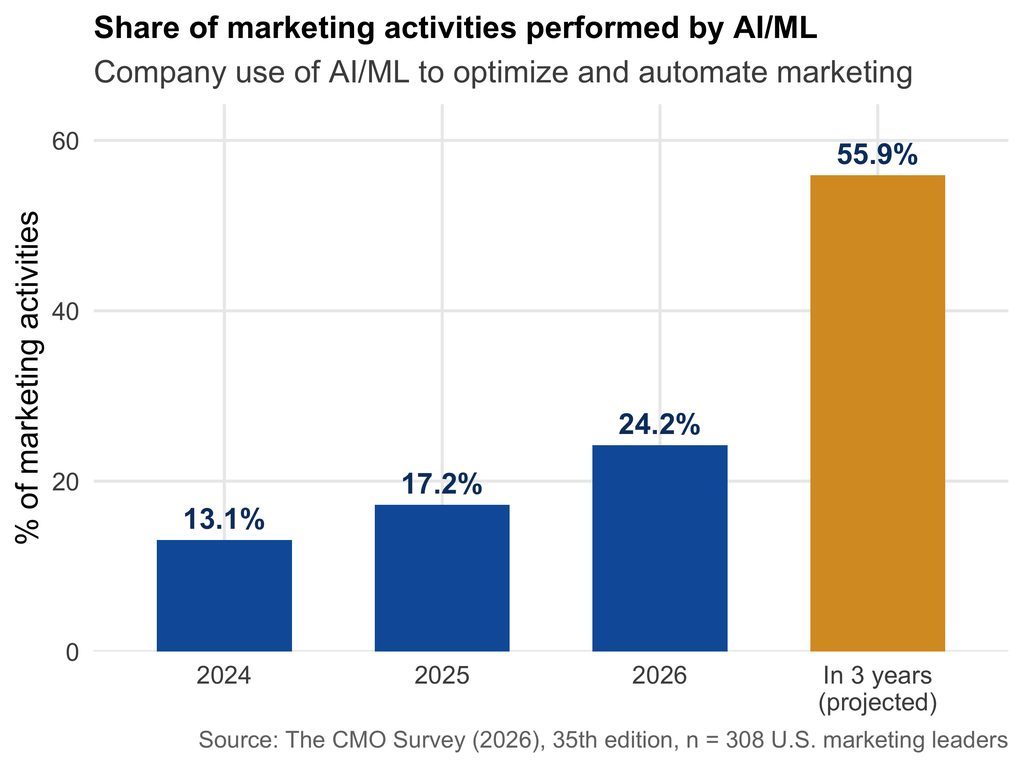

## … while budgets are flat: every euro must justify itself

1.7%

growth of total marketing spending — the **weakest since 2021**

15.3%

of marketing budgets now go to **AI initiatives**

78.2%

name **“higher ROI per marketing dollar”** as the #1 reason to build marketing capabilities

> “CMOs are being asked to deliver growth, efficiency and transformation **without meaningful budget expansion**. Those who succeed will make deliberate, **data-driven trade-offs**.”

> — Gartner CMO Spend Survey (2026)

Sources: The CMO Survey (2026); Gartner CMO Spend Survey (2026), n = 401 CMOs, North America & Europe.

## The scarce skill is judgment

**The ambition–readiness gap (Gartner 2026):**

- **70%** of CMOs: becoming an **AI leader** is a critical goal
- … but only **30%** are ready to **scale** AI capabilities

**The labor market (WEF Future of Jobs 2025):**

- **Analytical thinking = the #1 core skill** — 7 of 10 employers consider it essential
- **AI & big data = the fastest-growing skill** for 2025–2030

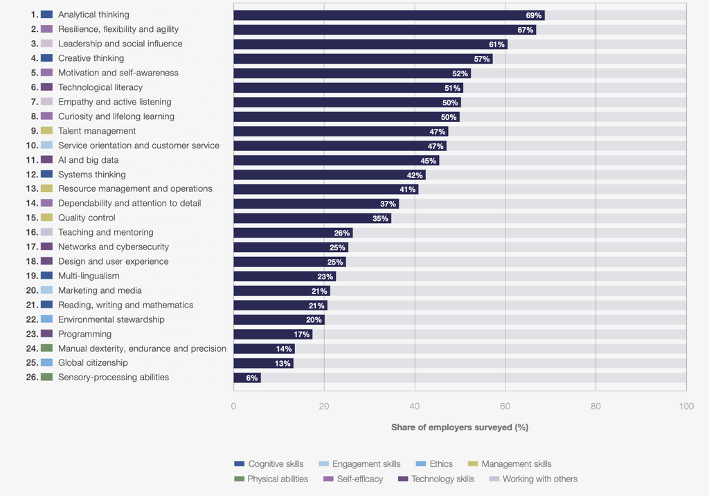

Source: World Economic Forum, Future of Jobs Report 2025

**The mechanical layer of marketing is being automated. What remains scarce is judgment:** knowing which analysis answers which managerial question, and whether the resulting number can be trusted.

## Who turns analytics into decisions?

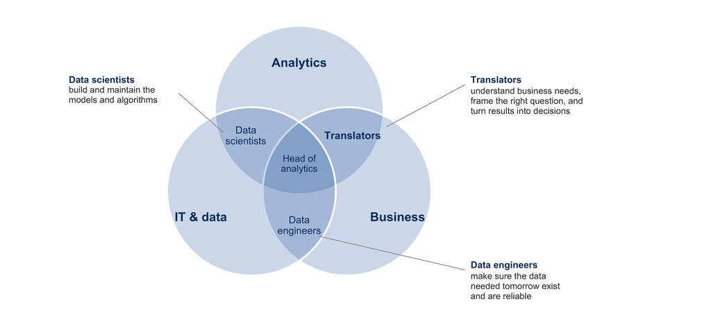

The **translator** role — framing the business question, choosing the right analysis, judging what the result does and does not show — is exactly what this course trains.

Own illustration; concept after Henke, Levine & McInerney (2018), “Analytics translator: The new must-have role”, *McKinsey Quarterly* ([link](https://www.mckinsey.com/capabilities/quantumblack/our-insights/analytics-translator)).

# 1.2 Case study: search advertising at eBay

## eBay, 2012: Does paid search advertising pay off?

[figure not shown]

Blake, Nosko & Tadelis (2015), “Consumer Heterogeneity and Paid Search Effectiveness: A Large-Scale Field Experiment”, *Econometrica*, 83(1), 155–174, Fig. 1 — Google results pages for the searches “used gibson les paul” and “macys”.

## eBay, 2012: what the dashboards showed

eBay spent **~ $50M per year** on paid search ads (Google, Bing, Yahoo). Here is how the return on this spending was measured:

1. A user types **“ebay guitar”** into Google and clicks eBay’s **paid ad** at the top of the results page
2. The **tracking parameter** in the URL logs her visit as *arrived via paid search* (with keyword & cost-per-click)
3. All other visitors are logged with a different **referrer** (organic search, other sites, direct) — and serve as the **comparison group**
4. Purchases within the **attribution window** are credited to the arrival channel → the picture on the right, and with it: **attributed revenue ÷ ad spend**, per keyword, updated daily

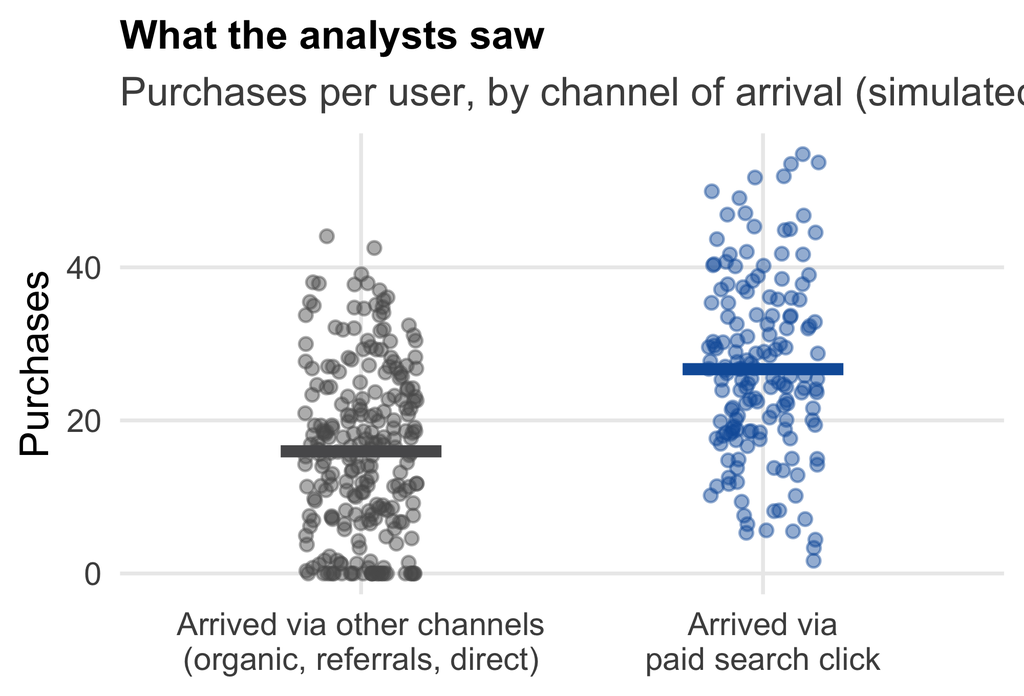

**Discuss (5 min):** As eBay’s CMO, would you sign off on next year’s $50M based on this evidence? If yes — what convinces you? If not — **how would you measure the payoff instead?**

## What happened when the ads were switched off

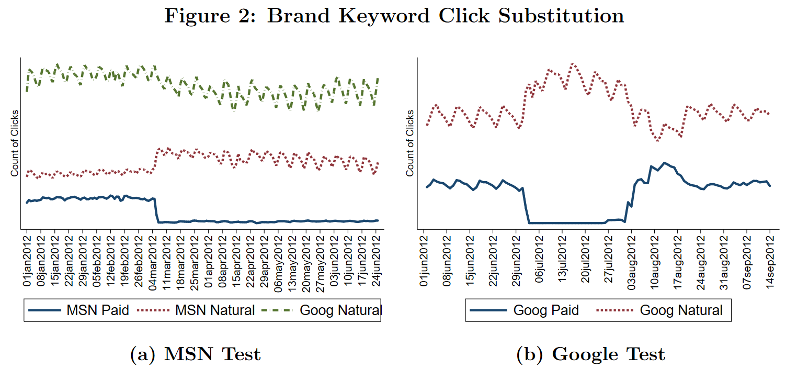

Paid clicks fell to zero — and **~99.5% of that traffic instantly reappeared via the free organic link**. Total visits to eBay: essentially unchanged.

Blake, Nosko & Tadelis (2015), “Consumer Heterogeneity and Paid Search Effectiveness: A Large-Scale Field Experiment”, *Econometrica*, 83(1), 155–174, Fig. 2 — brand-keyword ads halted on MSN (March 2012) and Google (July–August 2012); solid line: paid clicks, dotted: organic clicks.

## Reading the fine print

**Brand keywords (“ebay”, “ebay shoes”) — the platform halts:**

- The users clicking the ad were **already on their way to eBay** — the ad intercepted traffic the free organic link would have caught (**~99.5% substitution**)
- Attributed revenue: almost entirely **re-labeled, not created** → true effect of brand ads ≈ **zero**

**Non-brand keywords (“used guitar”) — the regional experiment:**

- Ads suspended in a **randomly selected ~30% of US regions for 60 days**; **total sales** compared against the remaining regions — a *real* comparison group, created by design
- Sales moved **only among new and infrequent users**; **frequent shoppers** — most of the clicks and most of the ad cost — were unmoved
- **The customers most likely to click were the customers least influenced** → averaged over everyone, returns on the spending: **negative**

Smart people, huge data, careful computation — and a conclusion off by tens of millions of dollars. **The problem was not the math. It was the comparison.**

Blake, Nosko & Tadelis (2015), *Econometrica* — details in the course book.

## Why the dashboard and the experiment disagree

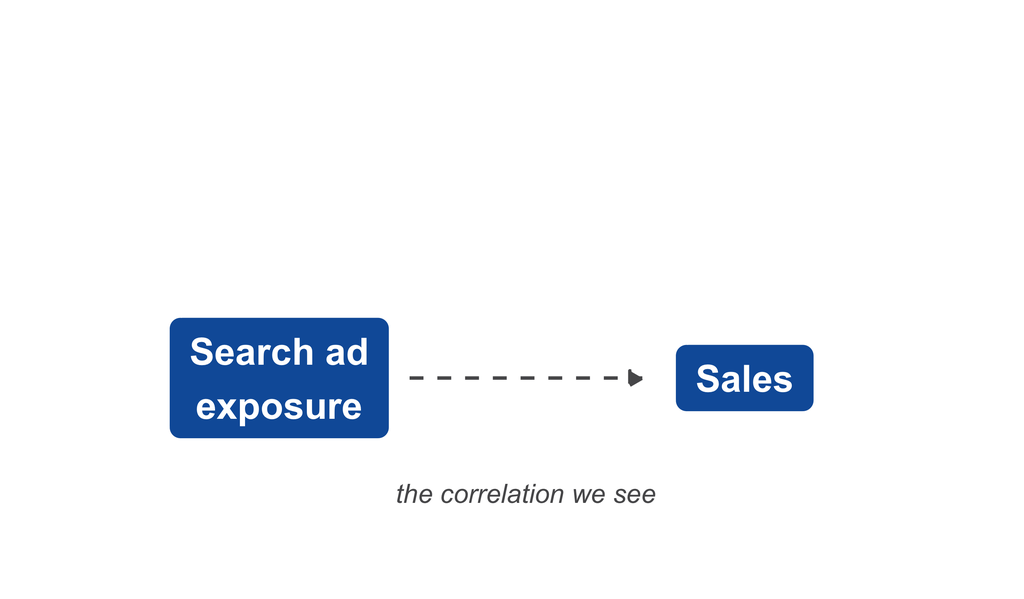

## Why the dashboard and the experiment disagree

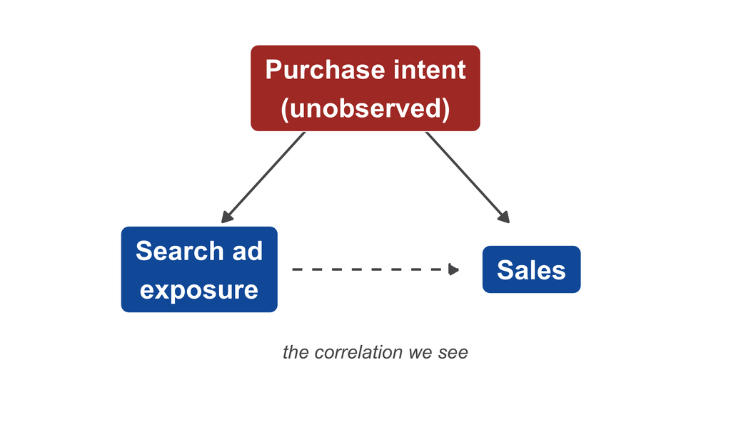

**Purchase intent drives both** who sees the ads *and* who buys. The dashboard’s correlation mixes the ad effect with the intent difference — and in this case, intent was nearly the whole story.

## The comparison that matters

**The causal question:** *What would eBay’s sales have been **without** the ads — everything else unchanged?*

|  | What eBay **observed** | What the decision **needs** |
| --- | --- | --- |
| Group A | Users arriving via **paid search** | The same users, **with** ads |
| Group B | Users arriving via **other channels** | **The same users, without ads** |
| The difference measures… | Ad effect **+ intent difference** | The ad effect. **Nothing else** |

The needed Group B is a **counterfactual** — a world we can never observe. All of causal inference is about **constructing a credible stand-in for it** — and how well a stand-in can be constructed depends on **how the data came into being**. This one idea organizes the entire course.

# 1.3 Types of research questions

## Every analytics task answers one of four questions

| # | Question | Type | Marketing examples |
| --- | --- | --- | --- |
| 1 | **What is going on?** | Descriptive | Segment sizes, churn rate, funnel drop-off, satisfaction tracking |
| 2 | **What will happen?** | Predictive | Which customers will churn next quarter? Demand next month? |
| 3 | **What happens if we act?** | Causal | Does the discount *cause* extra sales? Did the campaign work? |
| 4 | **What should we do?** | Prescriptive | Set the price; allocate budget across channels |

**Prescription requires causation.** To choose an action you must know what each action would *cause* — i.e., compare counterfactuals. Prediction alone is not enough… and confusing 2 with 3 was eBay’s mistake.

## Four types of questions, four kinds of analytics

|  | **Description** | **Prediction** | **Causal inference** | **Prescription** |
| --- | --- | --- | --- | --- |
| **Typical question** | How can our customers be grouped into segments based on their characteristics? | Which of last year’s visitors will purchase from our store next month? | Does behavioral targeting *increase* the probability of purchase — and by how much? | Which customers should we target, at what budget, to maximize profit? |
| **What the data must contain** | *Features:* user characteristics (age, location, …), products viewed, … | *Inputs* (features) and the *output* to be predicted (purchase next month) | *Outcome*, *treatment*, and — without an experiment — the relevant *confounders* | Causal effect estimates *plus* costs, margins, and constraints |
| **Typical analytics** | Cluster analysis, descriptive statistics, visualization | Regression, trees, random forests, neural networks | Randomized experiments; regression, diff-in-diff, IV, RDD | Targeting & uplift models, optimization, simulation |

Based on the classification of data-science tasks in Hernán, Hsu & Healy (2019), *Chance* — prescription column added.

## Prediction ≠ causation: same data, different questions

**“Customers who see our newsletter churn 40% less.”**

**As a predictive statement ✓**

Newsletter readership *predicts* retention — useful for **targeting**: flag non-readers as churn risks.

*Valid even if the newsletter does nothing.*

**As a causal statement ✗ (so far)**

“Send more newsletters → churn drops”?  
Only if readership *causes* retention — but engaged customers **both** read newsletters **and** stay.

*Requires a counterfactual comparison.*

**Classify these (2 min, neighbor discussion):** (a) “Which ad creative will get the highest CTR?” (b) “How large is our Gen-Z segment?” (c) “Should we raise the price by 5%?”

# 1.4 Correlation and causation

## Did Internet Explorer prevent murders?

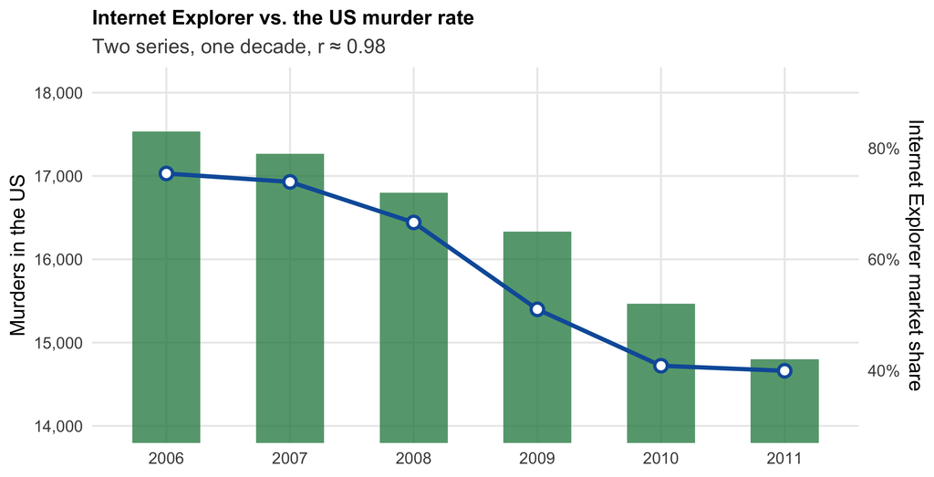

A **spurious correlation**: two variables move together **without any causal link** — here simply because both **trend in the same direction over time**. Correlation is cheap; causation is not.

Data: FBI Uniform Crime Reports; StatCounter (approx.). Hundreds more at tylervigen.com/spurious-correlations — chart style after the internet classic.

## Two pictures of “X relates to Y”

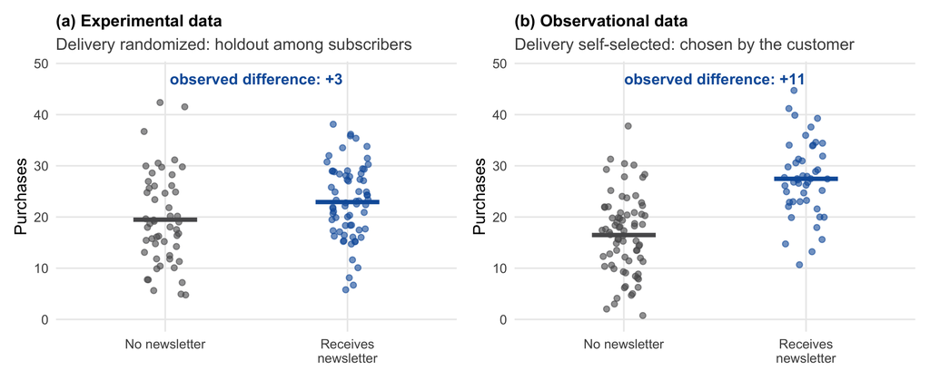

Same newsletter, same chart — **and the true effect is +3 in both worlds.** Panel (a) recovers it; panel (b) reports **+11**, because customers who subscribe differ from those who don’t *before* any newsletter arrives. Which panel is which is **invisible in the plot**: it lies in **how the data came to be** (the *data-generating process*).

## What generates panel (b)

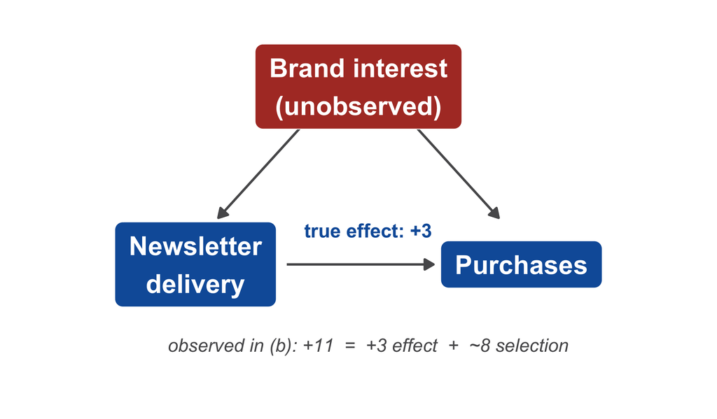

The confounder is the customer’s **underlying brand interest**: it makes people **subscribe** *and* it makes them **buy**. Randomizing delivery — panel (a) — cuts its left arrow, and only the **+3** remains (more on this later).

## Four ways to get the same scatter plot

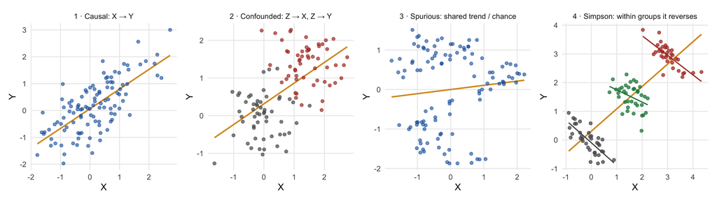

## The four data-generating processes

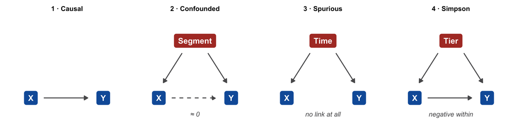

Four similar scatter plots — four different worlds. The plot shows the **correlation**; only the **DGP** says what X does to Y — and thus what happens if you **act on X**.

## Reverse causality: who is causing whom?

**Observed:** regions with higher ad spend show higher sales.

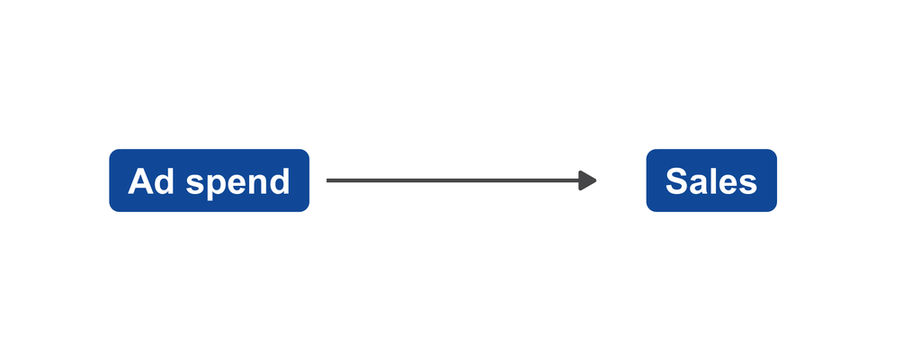

*Story 1:* advertising drives sales.

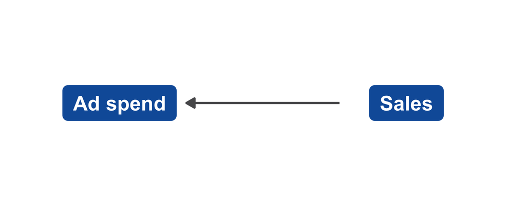

*Story 2:* budgets are **set as a % of sales** — sales drive ad spend.

Both stories produce identical data. Marketing budget rules make reverse causality a **routine** hazard in marketing data, not an exotic one.

## The classical conditions for causality

For X to be accepted as a **cause** of Y, three conditions must hold:

1. **Concomitant variation** — X and Y vary together as the hypothesis predicts. *The data establish this directly — all four scatter panels satisfy it. It is the cheap condition.*
2. **Temporal order** — the cause precedes the effect. *Sometimes checkable in data — but last slide’s ad-budget example shows how it fails: sales also drive spending.*
3. **Absence of other possible causal factors** — no alternative explanation accounts for the association. *No dataset can certify this on its own: intent, segments, time, tiers…*

The entire difficulty of causal inference is **condition 3** — and this course teaches **strategies for making it plausible**.

Classical formulation after Field, Miles & Field (2012) — see the course book, §1.4.

# 1.5 Variables and their roles

## The two lead roles

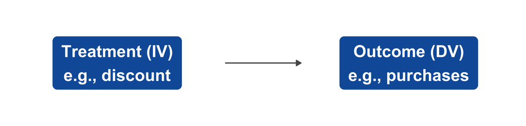

- **Dependent variable (DV)** — the *outcome*: the quantity the manager cares about (purchases, churn, willingness to pay)
- **Independent variable (IV)** — the *presumed cause*: the variable whose influence we want to establish (discount, ad exposure, price)
- In **experiments**, the independent variable under the researcher’s control is called the **treatment**; its values define the *experimental conditions* (treatment vs. control group)

Defining these two precisely — *whose* purchases, over *what horizon*, *which* discount — is half of research design (§1.8).

## The villain: the confounder

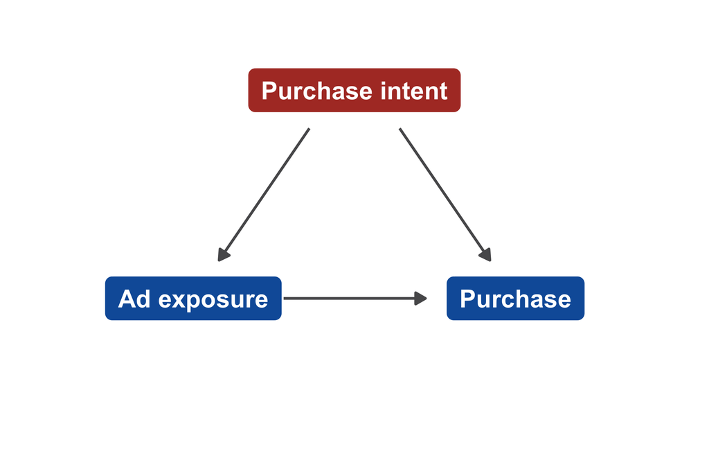

- Causes **both** treatment and outcome
- Creates correlation **without** causation — panel 2 of our gallery
- **The eBay confounder:** purchase intent → people search for “eBay” → see the ad → and buy anyway
- The *Observational data* sessions build the toolkit for dealing with confounders

When the confounding arises because units **choose their own exposure** — customers pick the channel, subscribe to the newsletter, install the app, join the loyalty program — the resulting distortion is called **selection bias**. In marketing data, it is the default, not the exception: *almost everything customers do, they chose to do.*

## Supporting roles: mediator and moderator

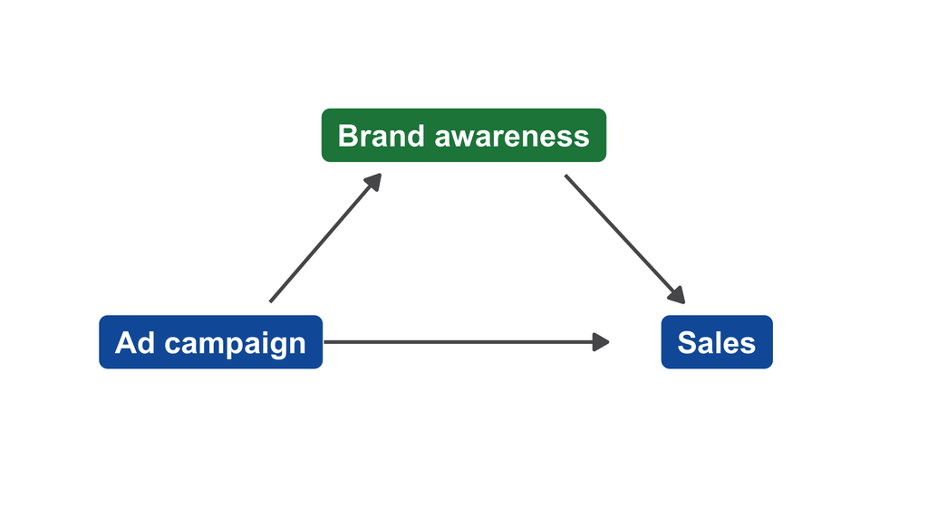

**Mediator — the *how***

Lies **on the path**: the mechanism through which X works.  
It tells you **what to optimize** (creative that builds awareness).

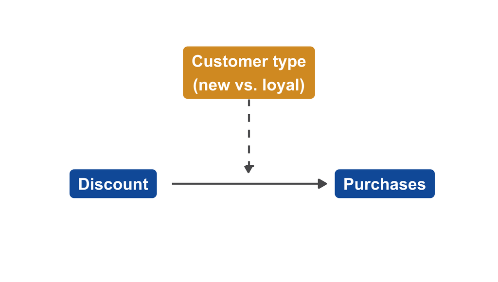

**Moderator — the *for whom / when***

Points **at the arrow**: changes the **strength** of the effect.  
“The discount works for new customers, not loyal ones.”

## The full cast around one causal question

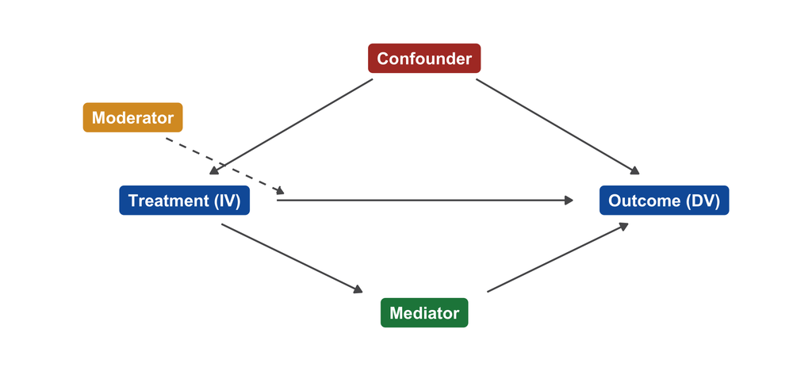

# 1.6 Randomization

## Randomization cuts every arrow into the treatment

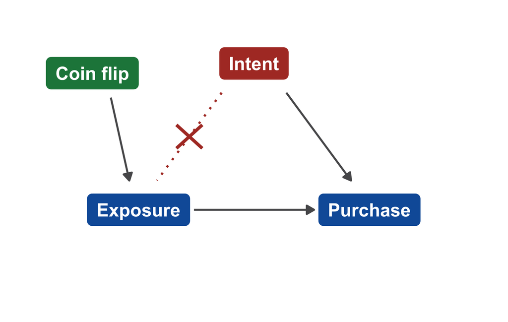

- Assignment depends **only on the coin** — not on intent, engagement, income, mood, …
- **Systematic variation** — differences in the outcome created **by the treatment**: this is what we want to measure
- **Unsystematic variation** — differences from everything else (age, mood, time of day, …): randomization spreads it **evenly across groups**
- So group differences = **treatment effect + noise**. No bias — and the noise is quantified in Module 3

Randomization does **not remove** other influences on the outcome — it makes them **unsystematic**: noise instead of bias. Noise averages out; bias does not.

## “Balanced — even on what we never measured”

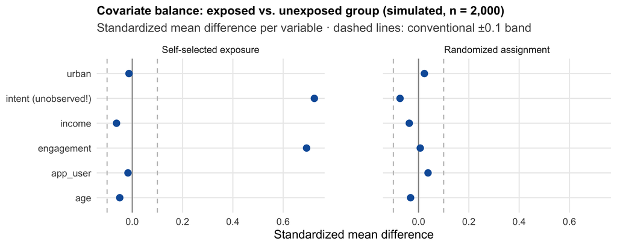

Left: the groups differ systematically — including on **intent**, which we (realistically) never observe. Right: one coin flip balances everything at once, **without knowing what needs balancing**.